# Problem Statement - Fantasy Sports Clustering Analysis

### Context:

Fantasy sports are online gaming platforms where participants draft and manage virtual teams of real professional sports players. Based on the performance of the players in the real world, players are allotted points in the fantasy sports platform every match. The objective is to create the best possible team with a fixed budget to score maximum fantasy points, and users compete against each other over an entire sports league or season. Some of these fantasy sports require actual financial investments for participation, with the chances of winning monetary rewards as well as free matchday tickets on a periodic basis.

The fantasy sports market has seen tremendous growth over the past few years, with a valuation of \$18.6 billion in 2019. The football (soccer) segment led in terms of market share in 2019, with over 8 million participants worldwide, and is expected to retain its dominance over the next couple of years. Digitalization is one of the primary factors driving the growth of the fantasy sports market as it allows participants the opportunity to compete on a global level and test their skills. With an increase in smartphone usage and availability of fantasy sports apps, this market is expected to witness a globe surge and reach a \\$48.6 billion valuation by 2027.

### Objective:

OnSports is a fantasy sports platform that has fantasy leagues for many different sports and has witnessed an increasing number of participants globally over the past 5 years. For each player, a price is set at the start, and the price keeps changing over time based on the performance of the players in the real world. With the new English Premier League season about to start, they have collected data from the past season and want to analyze it to determine the price of each player for the start of the new season. OnSports has hired you as a data scientist and asked you to conduct a cluster analysis to identify players of different potentials of each player based on previous season performance. This will help them understand the patterns in player performances and fantasy returns and decide the exact price to be set for each player for the upcoming football season.

Data Description: Player_Name: Name of the player.

- Club: Club in which the player plays.
- Position: Position in which the player plays.
- Goals_Scored: Number of goals scored by the player in the previous season.
- Assists: Number of passes made by the player leading to goals in the previous season.
- Total_Points: Total number of fantasy points scored by the player in the previous season.
- Minutes: Number of minutes played by the player in the previous season.
- Goals_Conceded: Number of goals conceded by the player in the previous season.
- Creativity: A score, computed using a range of stats, that assesses player performance in terms of producing goalscoring opportunities for other players.
- Influence: A score, computed using a range of stats, that evaluates a player's impact on a match, taking into account actions that could directly or indirectly affect the match outcome.
- Threat: A score, computed using a range of stats, that gauges players who are most likely to score goals.
- Bonus: Total bonus points received. The three best-performing players in each match receive additional bonus points based on a score computed using a range of stats. 3 points are awarded to the highest-scoring player, 2 to the second-best, and 1 to the third.
- Clean_Sheets: Number of matches without conceding a goal in the previous season.

```python
from google.colab import drive
drive.mount('/content/drive')
```

```python
import numpy as np
import pandas as pd
```

```python
pd.set_option('display.max_columns', 10)
pd.set_option('display.max_rows', 20)
```

```python
df = pd.read_csv("/content/drive/MyDrive/AIML-MIT/Making Sense of Unstructured Data/Guided Project/fpl_data.csv")
df.head()
```

|  | Player_Name | Club | Position | Goals_Scored | Assists | ... | Creativity | Influence | Threat | Bonus | Clean_Sheets |
| --- | --- | --- | --- | --- | --- | --- | --- | --- | --- | --- | --- |
| 0 | Alex Runnarsson | Arsenal | Goalkeeper | 0 | 0 | ... | 0.0 | 16.6 | 0 | 0 | 0 |
| 1 | Alexandre Lacazette | Arsenal | Forward | 13 | 3 | ... | 307.4 | 602.4 | 797 | 21 | 7 |
| 2 | Bernd Leno | Arsenal | Goalkeeper | 0 | 0 | ... | 0.0 | 702.2 | 2 | 11 | 11 |
| 3 | Bukayo Saka | Arsenal | Midfielder | 5 | 5 | ... | 650.6 | 493.0 | 984 | 8 | 8 |
| 4 | Calum Chambers | Arsenal | Defender | 0 | 3 | ... | 169.4 | 171.8 | 77 | 3 | 2 |

5 rows × 13 columns

```python
import matplotlib.pyplot as plt
import seaborn as sns
import warnings
warnings.filterwarnings('ignore')
```

# Clustering Analysis- Data Upload and Overview

```python
df = pd.read_csv("/content/drive/MyDrive/AIML-MIT/Making Sense of Unstructured Data/Guided Project/fpl_data.csv")
df.head()
```

|  | Player_Name | Club | Position | Goals_Scored | Assists | ... | Creativity | Influence | Threat | Bonus | Clean_Sheets |
| --- | --- | --- | --- | --- | --- | --- | --- | --- | --- | --- | --- |
| 0 | Alex Runnarsson | Arsenal | Goalkeeper | 0 | 0 | ... | 0.0 | 16.6 | 0 | 0 | 0 |
| 1 | Alexandre Lacazette | Arsenal | Forward | 13 | 3 | ... | 307.4 | 602.4 | 797 | 21 | 7 |
| 2 | Bernd Leno | Arsenal | Goalkeeper | 0 | 0 | ... | 0.0 | 702.2 | 2 | 11 | 11 |
| 3 | Bukayo Saka | Arsenal | Midfielder | 5 | 5 | ... | 650.6 | 493.0 | 984 | 8 | 8 |
| 4 | Calum Chambers | Arsenal | Defender | 0 | 3 | ... | 169.4 | 171.8 | 77 | 3 | 2 |

5 rows × 13 columns

```python
df.shape
```

```
(476, 13)
```

```python
df
```

|  | Player_Name | Club | Position | Goals_Scored | Assists | ... | Creativity | Influence | Threat | Bonus | Clean_Sheets |
| --- | --- | --- | --- | --- | --- | --- | --- | --- | --- | --- | --- |
| 0 | Alex Runnarsson | Arsenal | Goalkeeper | 0 | 0 | ... | 0.0 | 16.6 | 0 | 0 | 0 |
| 1 | Alexandre Lacazette | Arsenal | Forward | 13 | 3 | ... | 307.4 | 602.4 | 797 | 21 | 7 |
| 2 | Bernd Leno | Arsenal | Goalkeeper | 0 | 0 | ... | 0.0 | 702.2 | 2 | 11 | 11 |
| 3 | Bukayo Saka | Arsenal | Midfielder | 5 | 5 | ... | 650.6 | 493.0 | 984 | 8 | 8 |
| 4 | Calum Chambers | Arsenal | Defender | 0 | 3 | ... | 169.4 | 171.8 | 77 | 3 | 2 |
| ... | ... | ... | ... | ... | ... | ... | ... | ... | ... | ... | ... |
| 471 | Ruben Vinagre | Wolverhampton Wanderers | Defender | 0 | 0 | ... | 25.3 | 31.2 | 0 | 0 | 0 |
| 472 | Rui Pedro Patricio | Wolverhampton Wanderers | Goalkeeper | 0 | 0 | ... | 0.0 | 763.6 | 0 | 12 | 10 |
| 473 | Vitor Ferreira | Wolverhampton Wanderers | Midfielder | 0 | 1 | ... | 179.0 | 80.0 | 72 | 0 | 0 |
| 474 | Willian Jose | Wolverhampton Wanderers | Forward | 1 | 1 | ... | 165.9 | 89.6 | 256 | 3 | 5 |
| 475 | Willy Boly | Wolverhampton Wanderers | Defender | 1 | 1 | ... | 46.1 | 414.0 | 182 | 4 | 6 |

476 rows × 13 columns

```python
df.info()
```

```
<class 'pandas.core.frame.DataFrame'>
RangeIndex: 476 entries, 0 to 475
Data columns (total 13 columns):
 #   Column          Non-Null Count  Dtype
---  ------          --------------  -----
 0   Player_Name     476 non-null    object
 1   Club            476 non-null    object
 2   Position        476 non-null    object
 3   Goals_Scored    476 non-null    int64
 4   Assists         476 non-null    int64
 5   Total_Points    476 non-null    int64
 6   Minutes         476 non-null    int64
 7   Goals_Conceded  476 non-null    int64
 8   Creativity      476 non-null    float64
 9   Influence       476 non-null    float64
 10  Threat          476 non-null    int64
 11  Bonus           476 non-null    int64
 12  Clean_Sheets    476 non-null    int64
dtypes: float64(2), int64(8), object(3)
memory usage: 48.5+ KB
```

```python
df['Player_Name'].nunique()
```

```
476
```

```python
df.isnull().sum()
```

|  | 0 |
| --- | --- |
| Player_Name | 0 |
| Club | 0 |
| Position | 0 |
| Goals_Scored | 0 |
| Assists | 0 |
| Total_Points | 0 |
| Minutes | 0 |
| Goals_Conceded | 0 |
| Creativity | 0 |
| Influence | 0 |
| Threat | 0 |
| Bonus | 0 |
| Clean_Sheets | 0 |

**dtype:** int64

```python
df['Club'].nunique()
df['Club'].value_counts()
```

| Club | count |
| --- | --- |
| Arsenal | 30 |
| Crystal Palace | 30 |
| Leeds United | 29 |
| West Ham United | 29 |
| Tottenham Hotspurs | 29 |
| Newcastle United | 29 |
| Leicester City | 29 |
| Manchester United | 28 |
| Chelsea | 28 |
| Brighton and Hove Albion | 28 |
| Everton | 27 |
| Liverpool | 27 |
| Manchester City | 27 |
| Southampton | 27 |
| Burnley | 27 |
| Aston Villa | 26 |
| Wolverhampton Wanderers | 26 |

**dtype:** int64

```python
df['Position'].value_counts()
```

| Position | count |
| --- | --- |
| Midfielder | 195 |
| Defender | 172 |
| Forward | 64 |
| Goalkeeper | 45 |

**dtype:** int64

```python
print(df['Goals_Scored'].quantile(0.25))
print(df['Goals_Scored'].quantile(0.5))
print(df['Goals_Scored'].quantile(0.75))
df[df['Goals_Scored'] == 0]
```

```
0.0
0.5
2.0
```

|  | Player_Name | Club | Position | Goals_Scored | Assists | ... | Creativity | Influence | Threat | Bonus | Clean_Sheets |
| --- | --- | --- | --- | --- | --- | --- | --- | --- | --- | --- | --- |
| 0 | Alex Runnarsson | Arsenal | Goalkeeper | 0 | 0 | ... | 0.0 | 16.6 | 0 | 0 | 0 |
| 2 | Bernd Leno | Arsenal | Goalkeeper | 0 | 0 | ... | 0.0 | 702.2 | 2 | 11 | 11 |
| 4 | Calum Chambers | Arsenal | Defender | 0 | 3 | ... | 169.4 | 171.8 | 77 | 3 | 2 |
| 5 | Cedric Soares | Arsenal | Defender | 0 | 1 | ... | 114.8 | 110.8 | 66 | 3 | 2 |
| 6 | Daniel Ceballos | Arsenal | Midfielder | 0 | 4 | ... | 422.3 | 359.8 | 141 | 7 | 6 |
| ... | ... | ... | ... | ... | ... | ... | ... | ... | ... | ... | ... |
| 464 | Owen Otasowie | Wolverhampton Wanderers | Midfielder | 0 | 1 | ... | 25.9 | 38.2 | 34 | 0 | 0 |
| 465 | Patrick Cutrone | Wolverhampton Wanderers | Forward | 0 | 0 | ... | 0.0 | 0.0 | 4 | 0 | 0 |
| 471 | Ruben Vinagre | Wolverhampton Wanderers | Defender | 0 | 0 | ... | 25.3 | 31.2 | 0 | 0 | 0 |
| 472 | Rui Pedro Patricio | Wolverhampton Wanderers | Goalkeeper | 0 | 0 | ... | 0.0 | 763.6 | 0 | 12 | 10 |
| 473 | Vitor Ferreira | Wolverhampton Wanderers | Midfielder | 0 | 1 | ... | 179.0 | 80.0 | 72 | 0 | 0 |

238 rows × 13 columns

```python
df.describe(include = 'all')
```

|  | Player_Name | Club | Position | Goals_Scored | Assists | ... | Creativity | Influence | Threat | Bonus | Clean_Sheets |
| --- | --- | --- | --- | --- | --- | --- | --- | --- | --- | --- | --- |
| count | 476 | 476 | 476 | 476.000000 | 476.000000 | ... | 476.000000 | 476.000000 | 476.000000 | 476.000000 | 476.000000 |
| unique | 476 | 17 | 4 | NaN | NaN | ... | NaN | NaN | NaN | NaN | NaN |
| top | Alex Runnarsson | Arsenal | Midfielder | NaN | NaN | ... | NaN | NaN | NaN | NaN | NaN |
| freq | 1 | 30 | 195 | NaN | NaN | ... | NaN | NaN | NaN | NaN | NaN |
| mean | NaN | NaN | NaN | 1.907563 | 1.752101 | ... | 195.976050 | 294.617647 | 224.962185 | 4.718487 | 4.745798 |
| std | NaN | NaN | NaN | 3.455562 | 2.708563 | ... | 251.478541 | 267.779681 | 318.240377 | 6.252625 | 4.394312 |
| min | NaN | NaN | NaN | 0.000000 | 0.000000 | ... | 0.000000 | 0.000000 | 0.000000 | 0.000000 | 0.000000 |
| 25% | NaN | NaN | NaN | 0.000000 | 0.000000 | ... | 8.300000 | 46.500000 | 5.750000 | 0.000000 | 0.000000 |
| 50% | NaN | NaN | NaN | 0.500000 | 0.000000 | ... | 96.950000 | 233.100000 | 104.500000 | 2.000000 | 4.000000 |
| 75% | NaN | NaN | NaN | 2.000000 | 2.000000 | ... | 296.950000 | 499.500000 | 298.250000 | 7.000000 | 8.000000 |
| max | NaN | NaN | NaN | 23.000000 | 14.000000 | ... | 1414.900000 | 1318.200000 | 1980.000000 | 40.000000 | 19.000000 |

11 rows × 13 columns

```python
df.isnull().sum().sum()
```

```
0
```

```python
df[df.duplicated()]
```

|  | Player_Name | Club | Position | Goals_Scored | Assists | ... | Creativity | Influence | Threat | Bonus | Clean_Sheets |
| --- | --- | --- | --- | --- | --- | --- | --- | --- | --- | --- | --- |

0 rows × 13 columns

# Univariate and Bivariate Analysis - Numerical Features

```python
import matplotlib.pyplot as plt
import seaborn as sns
import warnings
warnings.filterwarnings('ignore')
```

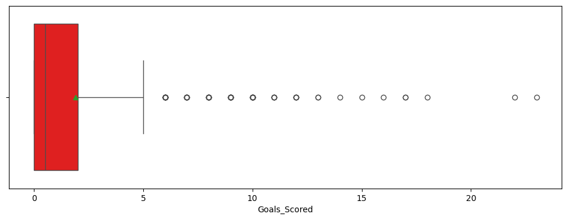

```python
plt.figure(figsize = (12,4))
sns.boxplot(df['Goals_Scored'], orient='h', showmeans = True, color='red')
```

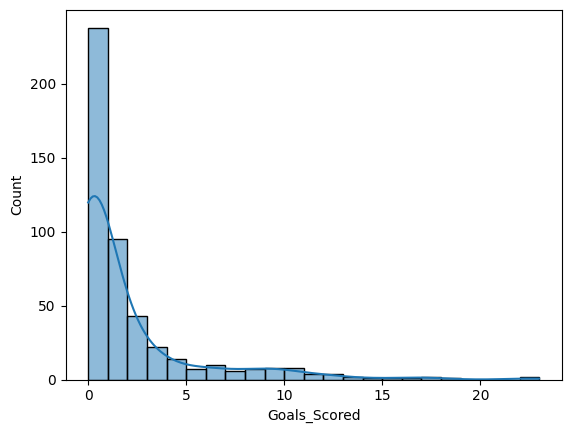

```python
sns.histplot(df['Goals_Scored'], bins=23, kde=True )
```

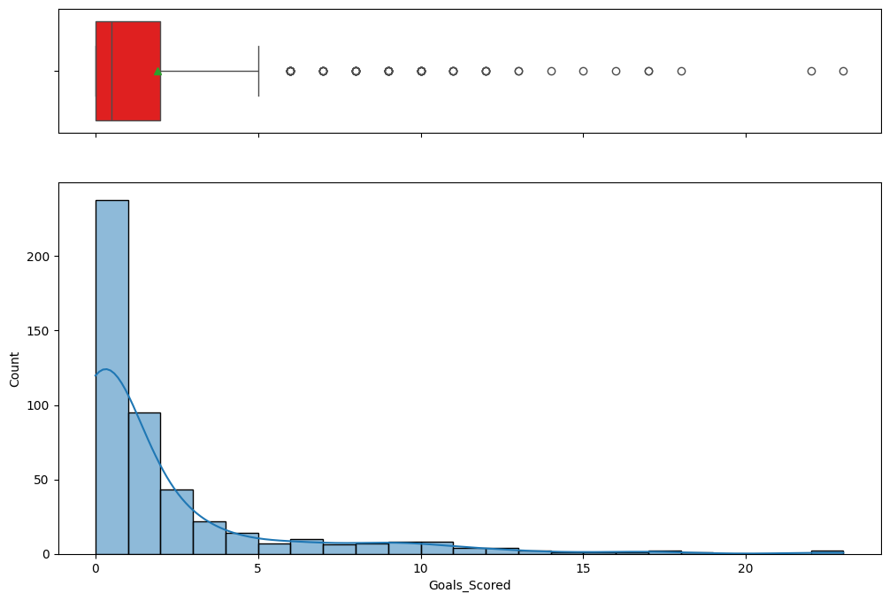

```python
fig, ax = plt.subplots(2, 1, sharex=True, gridspec_kw={'height_ratios': (1,3)},figsize=(12, 8))
sns.boxplot(df['Goals_Scored'], orient='h', showmeans = True, color='red', ax = ax[0])
sns.histplot(df['Goals_Scored'], bins=23, kde=True, ax = ax[1])
```

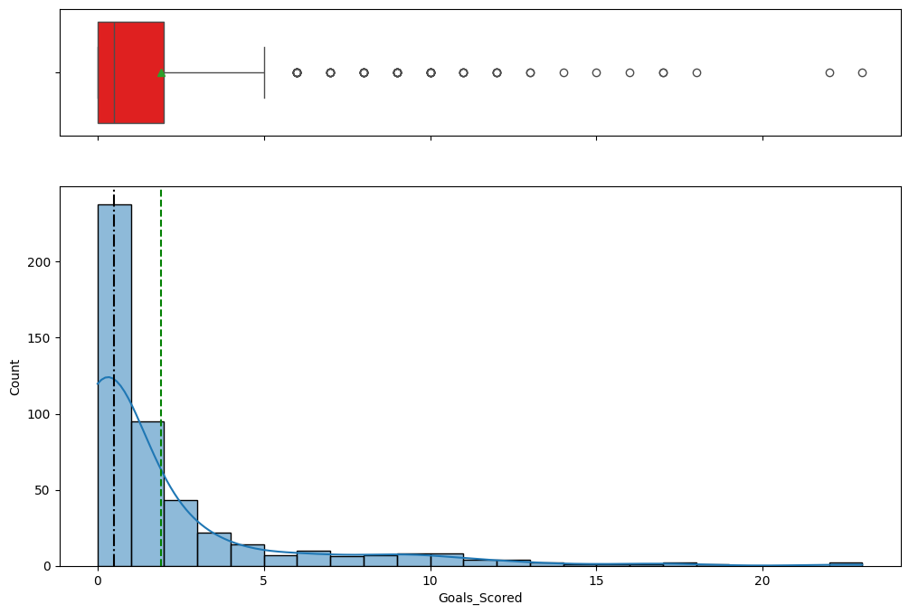

```python
fig, ax = plt.subplots(2, 1, sharex=True, gridspec_kw={'height_ratios': (1,3)},figsize=(12, 8))
sns.boxplot(df['Goals_Scored'], orient='h', showmeans = True, color='red', ax = ax[0])
sns.histplot(df['Goals_Scored'], bins=23, kde=True, ax = ax[1])
ax[1].axvline(x=df['Goals_Scored'].mean(), color='green', linestyle='--')
ax[1].axvline(x=df['Goals_Scored'].median(), color='black', linestyle='-.')
```

```python
df.columns
for fig_column in df.columns:
  print(fig_column)

print("----------")
for fig_column in df.select_dtypes(include=['int64', 'float64']):
  print(fig_column)
```

```
Player_Name
Club
Position
Goals_Scored
Assists
Total_Points
Minutes
Goals_Conceded
Creativity
Influence
Threat
Bonus
Clean_Sheets
----------
Goals_Scored
Assists
Total_Points
Minutes
Goals_Conceded
Creativity
Influence
Threat
Bonus
Clean_Sheets
```

```python
def hist_box_plot_column(df):
  for fig_column in df.select_dtypes(include=['int64', 'float64']):
    fig, ax = plt.subplots(2, 1, sharex=True, gridspec_kw={'height_ratios': (1,3)},figsize=(12, 8))
    sns.boxplot(df[fig_column], orient='h', showmeans = True, color='red', ax = ax[0])
    sns.histplot(df[fig_column], bins=10, kde=True, ax = ax[1])
    ax[1].axvline(x=df[fig_column].mean(), color='green', linestyle='--')
    ax[1].axvline(x=df[fig_column].median(), color='black', linestyle='-.')
```

```python
def hist_box_plot_by_feature(df, feature):
  fig, ax = plt.subplots(2, 1, sharex=True, gridspec_kw={'height_ratios': (1,3)},figsize=(12, 8))
  sns.boxplot(df[feature], orient='h', showmeans = True, color='red', ax = ax[0])
  sns.histplot(df[feature], bins=10, kde=True, ax = ax[1])
  ax[1].axvline(x=df[feature].mean(), color='green', linestyle='--')
  ax[1].axvline(x=df[feature].median(), color='black', linestyle='-.')
```

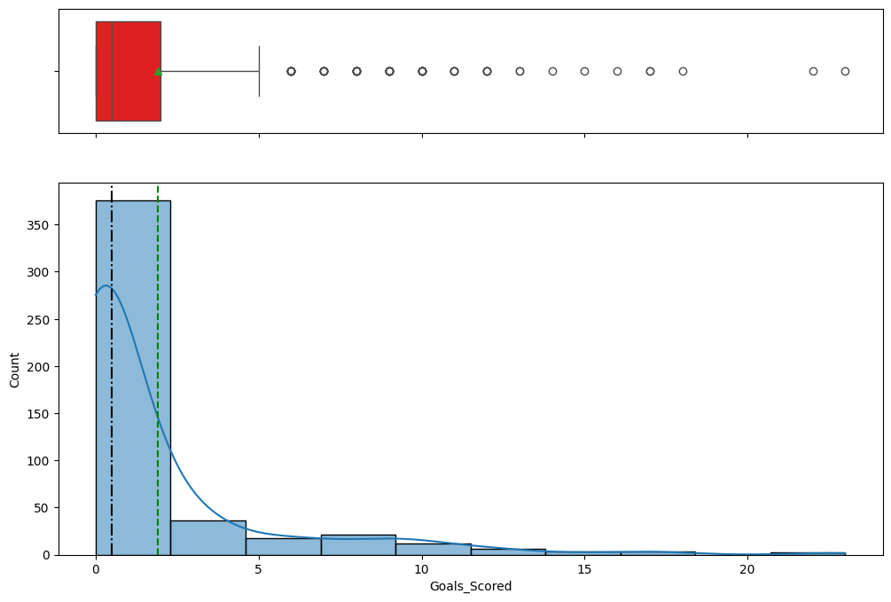

```python
hist_box_plot_by_feature(df, 'Goals_Scored')
```

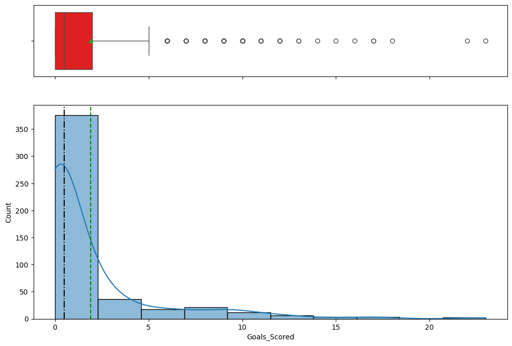

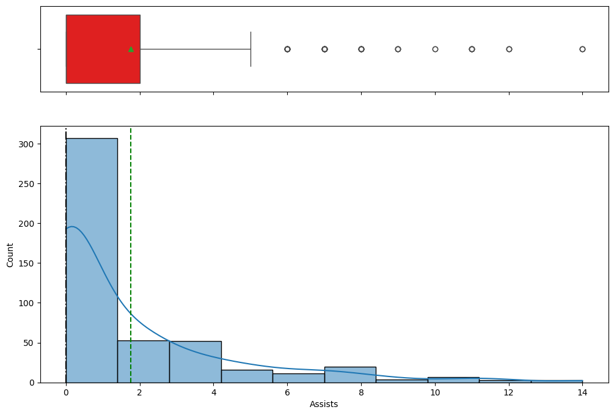

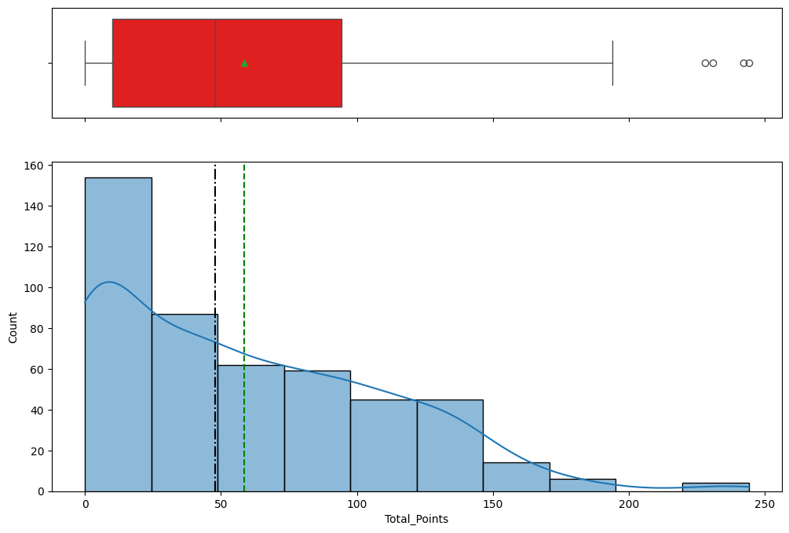

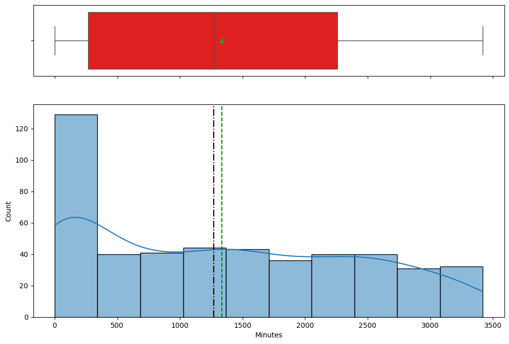

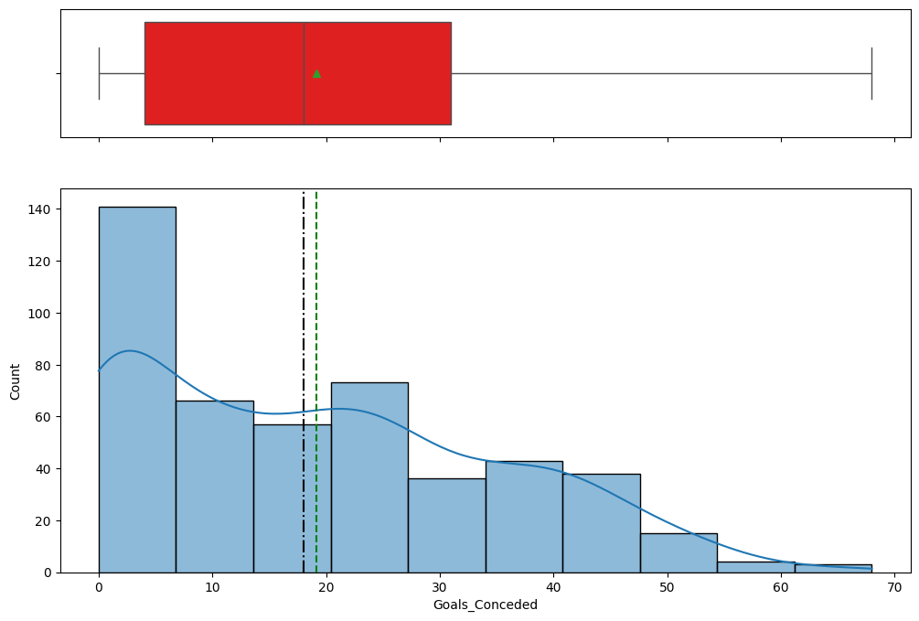

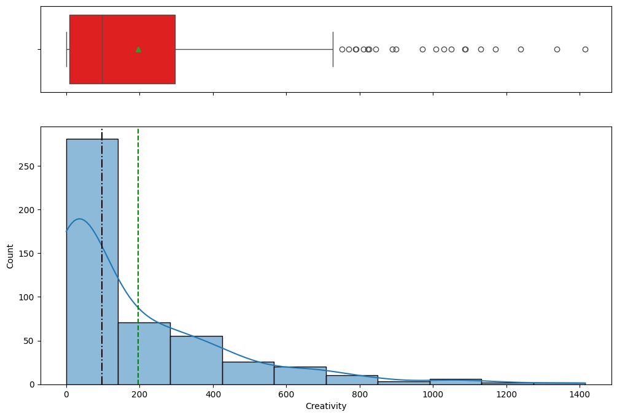

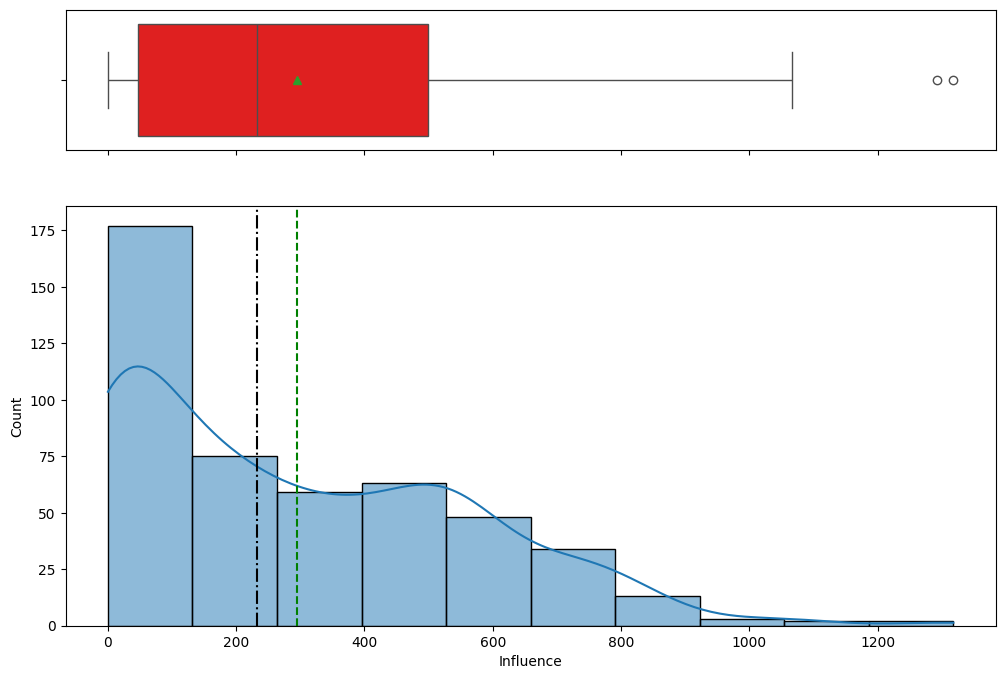

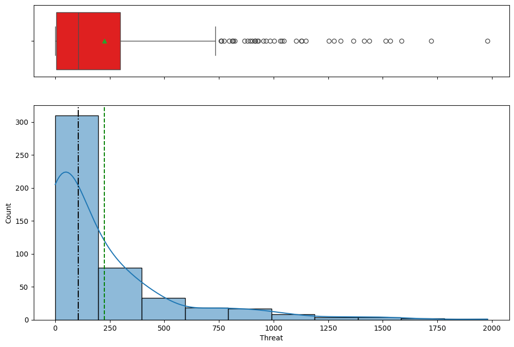

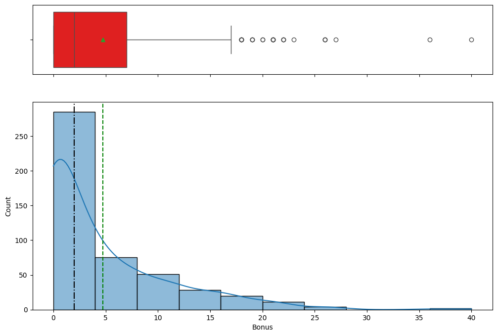

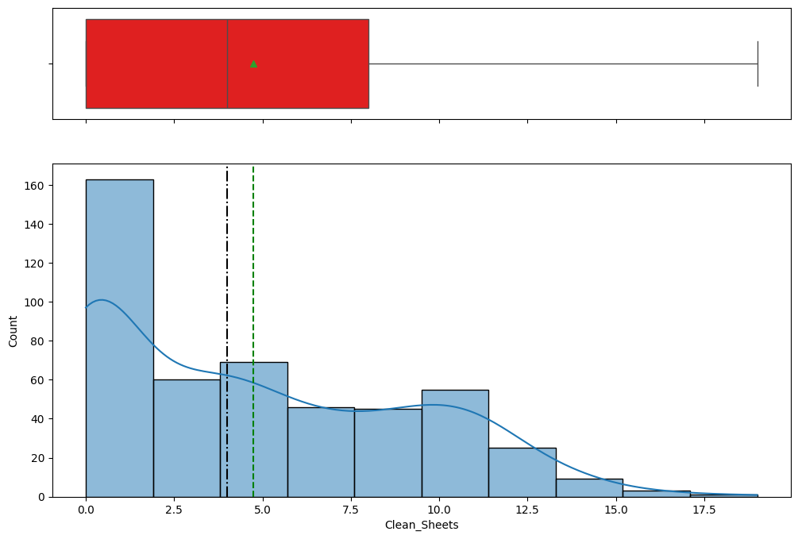

```python
hist_box_plot_column(df)
```

```python
df.select_dtypes(include=['int64', 'float64'])
```

|  | Goals_Scored | Assists | Total_Points | Minutes | Goals_Conceded | Creativity | Influence | Threat | Bonus | Clean_Sheets |
| --- | --- | --- | --- | --- | --- | --- | --- | --- | --- | --- |
| 0 | 0 | 0 | 1 | 15 | 0 | 0.0 | 16.6 | 0 | 0 | 0 |
| 1 | 13 | 3 | 129 | 1916 | 21 | 307.4 | 602.4 | 797 | 21 | 7 |
| 2 | 0 | 0 | 131 | 3131 | 37 | 0.0 | 702.2 | 2 | 11 | 11 |
| 3 | 5 | 5 | 114 | 2554 | 31 | 650.6 | 493.0 | 984 | 8 | 8 |
| 4 | 0 | 3 | 36 | 751 | 10 | 169.4 | 171.8 | 77 | 3 | 2 |
| ... | ... | ... | ... | ... | ... | ... | ... | ... | ... | ... |
| 471 | 0 | 0 | 1 | 172 | 7 | 25.3 | 31.2 | 0 | 0 | 0 |
| 472 | 0 | 0 | 132 | 3330 | 51 | 0.0 | 763.6 | 0 | 12 | 10 |
| 473 | 0 | 1 | 26 | 509 | 8 | 179.0 | 80.0 | 72 | 0 | 0 |
| 474 | 1 | 1 | 40 | 1106 | 13 | 165.9 | 89.6 | 256 | 3 | 5 |
| 475 | 1 | 1 | 68 | 1879 | 29 | 46.1 | 414.0 | 182 | 4 | 6 |

476 rows × 10 columns

```python
df[df['Total_Points'] >= 180]
```

|  | Player_Name | Club | Position | Goals_Scored | Assists | ... | Creativity | Influence | Threat | Bonus | Clean_Sheets |
| --- | --- | --- | --- | --- | --- | --- | --- | --- | --- | --- | --- |
| 36 | Emiliano Martinez | Aston Villa | Goalkeeper | 0 | 0 | ... | 20.0 | 1067.2 | 0 | 27 | 15 |
| 219 | Patrick Bamford | Leeds United | Forward | 17 | 11 | ... | 371.0 | 867.2 | 1512 | 26 | 10 |
| 238 | Jamie Vardy | Leicester City | Forward | 15 | 14 | ... | 356.6 | 819.2 | 1306 | 23 | 8 |
| 269 | Mohamed Salah | Liverpool | Midfielder | 22 | 6 | ... | 825.7 | 1056.0 | 1980 | 21 | 11 |
| 315 | Bruno Fernandes | Manchester United | Midfielder | 18 | 14 | ... | 1414.9 | 1292.6 | 1253 | 36 | 13 |
| 403 | Harry Kane | Tottenham Hotspurs | Forward | 23 | 14 | ... | 659.1 | 1318.2 | 1585 | 40 | 12 |
| 405 | Heung-Min Son | Tottenham Hotspurs | Midfielder | 17 | 11 | ... | 1049.9 | 1052.2 | 1046 | 26 | 13 |

7 rows × 13 columns

# Univariate and Bivariate Analysis - Categorical Features

```python
import matplotlib.pyplot as plt
import seaborn as sns
import warnings
warnings.filterwarnings('ignore')
```

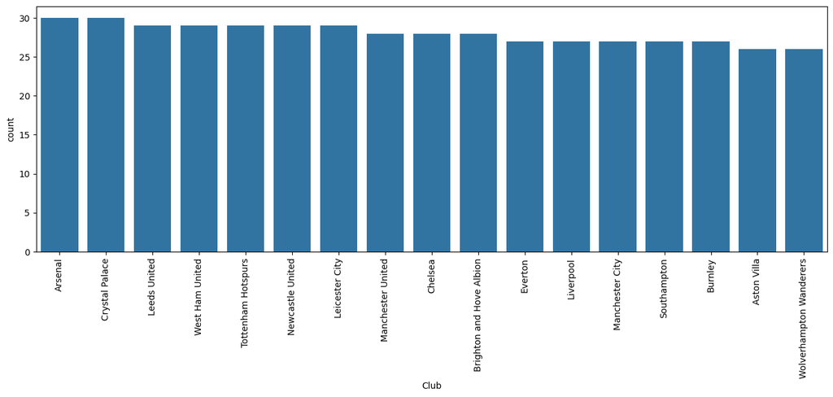

```python
plt.figure(figsize = (16,5))
sns.countplot(data=df, x='Club', order=df.groupby(['Club'])['Player_Name'].count().sort_values(ascending=False).index)
plt.xticks(rotation=90);
```

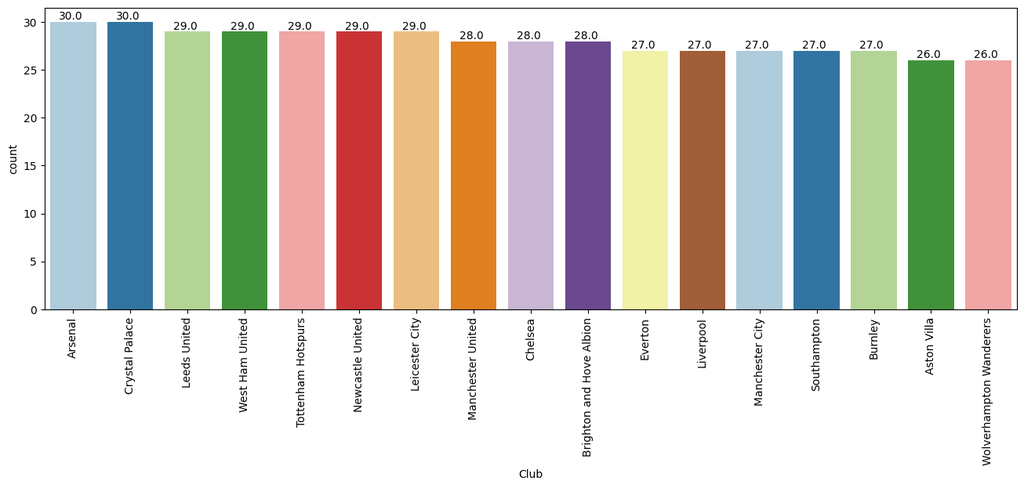

```python
plt.figure(figsize = (16,5))
ax = sns.countplot(data=df, x='Club', palette = "Paired", order=df.groupby(['Club'])['Player_Name'].count().sort_values(ascending=False).index)
plt.xticks(rotation=90);


i = 0
for i in range(len(ax.patches)):
  x = ax.patches[i].get_x() + ax.patches[i].get_width()/2 - 0.25
  y = ax.patches[i].get_y() + ax.patches[i].get_height() + 0.25
  ax.annotate(ax.patches[i].get_height(), (x, y));
# for p in ax.patches:
#   width = p.get_width()

#Seaborn in fact has six variations of matplotlib’s palette, called deep, muted, pastel, bright, dark, and colorblind
```

```python
#df.groupby('Club').size().sort_values(ascending=False)
df.groupby(['Club'])['Player_Name'].count().sort_values(ascending=False).index
```

```
Index(['Arsenal', 'Crystal Palace', 'Leeds United', 'West Ham United',
       'Tottenham Hotspurs', 'Newcastle United', 'Leicester City',
       'Manchester United', 'Chelsea', 'Brighton and Hove Albion', 'Everton',
       'Liverpool', 'Manchester City', 'Southampton', 'Burnley', 'Aston Villa',
       'Wolverhampton Wanderers'],
      dtype='object', name='Club')
```

```python
#ax.patches
print(ax.patches[0].get_x())
print(ax.patches[0].get_y())
print(ax.patches[0].get_height())
print(ax.patches[0].get_width())
```

```
-0.4
0
30.0
0.8
```

- Function to create labeled barplots

```python
# Function to create labeled barplots

def labeled_barplot(data, feature, perc = False, n = None):
    """
    Barplot with percentage at the top

    data: dataframe
    feature: dataframe column
    perc: whether to display percentages instead of count (default is False)
    n: displays the top n category levels (default is None, i.e., display all levels)
    """

    total = len(data[feature])  # Length of the column
    count = data[feature].nunique()
    if n is None:
        plt.figure(figsize = (count + 1, 5))
    else:
        plt.figure(figsize = (n + 1, 5))

    plt.xticks(rotation = 90, fontsize = 15)
    ax = sns.countplot(
        data = data,
        x = feature,
        palette = "Paired",
        order = data[feature].value_counts().index[:n].sort_values(),
    )

    for p in ax.patches:
        if perc == True:
            label = "{:.1f}%".format(
                100 * p.get_height() / total
            )                       # Percentage of each class of the category
        else:
            label = p.get_height()  # Count of each level of the category

        x = p.get_x() + p.get_width() / 2  # Width of the plot
        y = p.get_height()                 # Height of the plot

        ax.annotate(
            label,
            (x, y),
            ha = "center",
            va = "center",
            size = 12,
            xytext = (0, 5),
            textcoords = "offset points",
        )  # Annotate the percentage

    plt.show()  # Show the plot
```

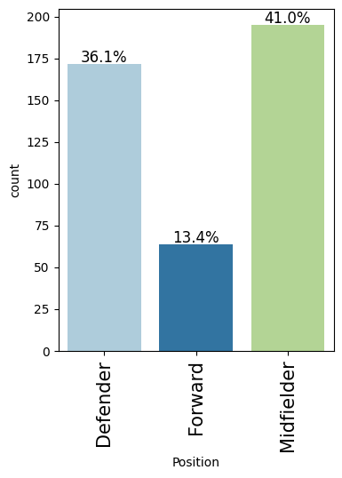

```python
labeled_barplot(df, 'Position', perc=True, n=3)
```

```python
# Correlation check
df_numeric = df.select_dtypes(include='number')
cols_list = df.select_dtypes(include = np.number).columns.tolist()
print(df_numeric.columns)
print(cols_list)

df_numeric.corr()
```

```
Index(['Goals_Scored', 'Assists', 'Total_Points', 'Minutes', 'Goals_Conceded',
       'Creativity', 'Influence', 'Threat', 'Bonus', 'Clean_Sheets'],
      dtype='object')
['Goals_Scored', 'Assists', 'Total_Points', 'Minutes', 'Goals_Conceded', 'Creativity', 'Influence', 'Threat', 'Bonus', 'Clean_Sheets']
```

|  | Goals_Scored | Assists | Total_Points | Minutes | Goals_Conceded | Creativity | Influence | Threat | Bonus | Clean_Sheets |
| --- | --- | --- | --- | --- | --- | --- | --- | --- | --- | --- |
| Goals_Scored | 1.000000 | 0.658168 | 0.696172 | 0.436865 | 0.381064 | 0.554242 | 0.597638 | 0.903802 | 0.738927 | 0.434619 |
| Assists | 0.658168 | 1.000000 | 0.701306 | 0.519280 | 0.449536 | 0.825242 | 0.591190 | 0.748933 | 0.666646 | 0.520733 |
| Total_Points | 0.696172 | 0.701306 | 1.000000 | 0.908206 | 0.801821 | 0.709679 | 0.955050 | 0.723896 | 0.867282 | 0.894135 |
| Minutes | 0.436865 | 0.519280 | 0.908206 | 1.000000 | 0.940025 | 0.613385 | 0.938259 | 0.524276 | 0.676415 | 0.917858 |
| Goals_Conceded | 0.381064 | 0.449536 | 0.801821 | 0.940025 | 1.000000 | 0.532461 | 0.861307 | 0.458876 | 0.587797 | 0.758916 |
| Creativity | 0.554242 | 0.825242 | 0.709679 | 0.613385 | 0.532461 | 1.000000 | 0.639369 | 0.659140 | 0.638027 | 0.619753 |
| Influence | 0.597638 | 0.591190 | 0.955050 | 0.938259 | 0.861307 | 0.639369 | 1.000000 | 0.613462 | 0.817605 | 0.882480 |
| Threat | 0.903802 | 0.748933 | 0.723896 | 0.524276 | 0.458876 | 0.659140 | 0.613462 | 1.000000 | 0.687508 | 0.520807 |
| Bonus | 0.738927 | 0.666646 | 0.867282 | 0.676415 | 0.587797 | 0.638027 | 0.817605 | 0.687508 | 1.000000 | 0.670131 |
| Clean_Sheets | 0.434619 | 0.520733 | 0.894135 | 0.917858 | 0.758916 | 0.619753 | 0.882480 | 0.520807 | 0.670131 | 1.000000 |

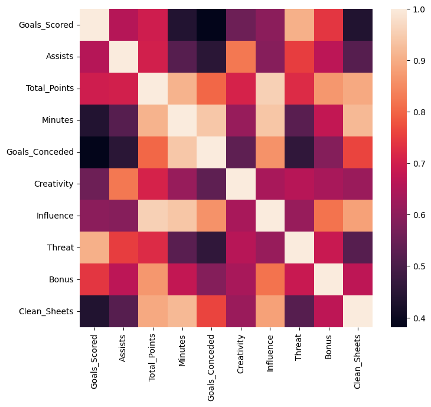

```python
plt.figure(figsize = (8, 7))
sns.heatmap(df_numeric.corr())
plt.show()
```

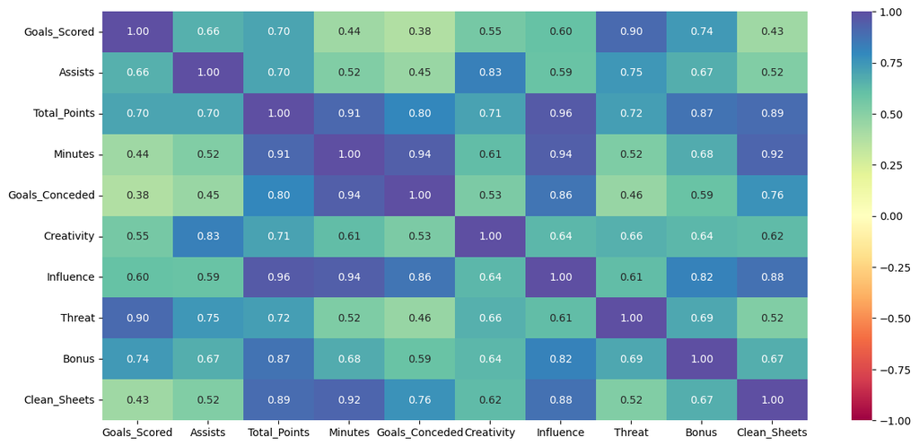

```python
cols_list = df.select_dtypes(include = np.number).columns.tolist()

plt.figure(figsize = (15, 7))

sns.heatmap(
    df[cols_list].corr(numeric_only = True), annot = True, vmin = -1, vmax = 1, fmt = ".2f", cmap = "Spectral"
)

plt.show()
```

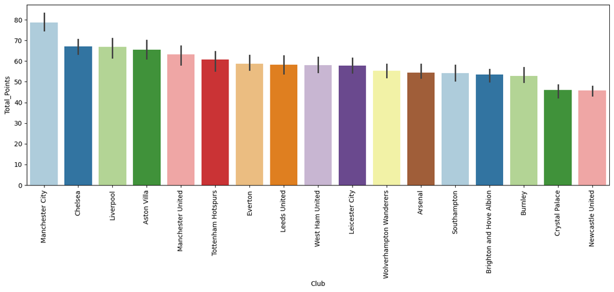

```python
plt.figure(figsize = (16,5))
sns.barplot(data=df, x='Club', y='Total_Points', ci=30, palette = "Paired", order = df.groupby(['Club'])['Total_Points'].mean().sort_values(ascending=False).index)
plt.xticks(rotation=90);
```

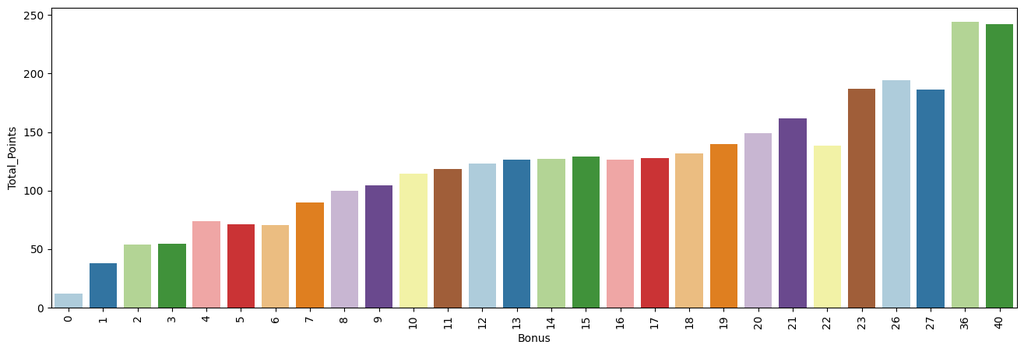

```python
plt.figure(figsize = (16,5))
sns.barplot(data=df, x='Bonus', y='Total_Points', errorbar=('ci', False), palette = "Paired")
plt.xticks(rotation=90);
```

```python
df.groupby(['Club'])['Total_Points'].mean().sort_values(ascending=False)
```

| Club | Total_Points |
| --- | --- |
| Manchester City | 78.666667 |
| Chelsea | 67.142857 |
| Liverpool | 66.851852 |
| Aston Villa | 65.615385 |
| Manchester United | 63.214286 |
| Tottenham Hotspurs | 60.689655 |
| Everton | 58.629630 |
| Leeds United | 58.310345 |
| West Ham United | 58.137931 |
| Leicester City | 57.896552 |
| Wolverhampton Wanderers | 55.423077 |
| Arsenal | 54.400000 |
| Southampton | 54.259259 |
| Brighton and Hove Albion | 53.464286 |
| Burnley | 52.925926 |
| Crystal Palace | 45.966667 |
| Newcastle United | 45.758621 |

**dtype:** float64

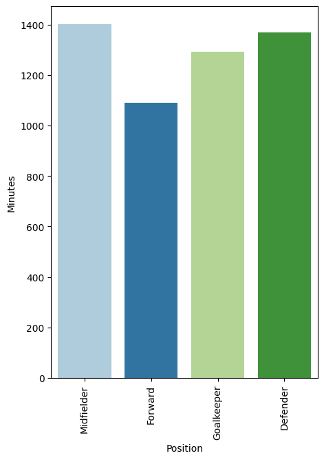

```python
plt.figure(figsize = (5,7))
sns.barplot(data=df, x='Position', y='Minutes', ci=None, palette = "Paired", order = df.groupby(['Position'])['Total_Points'].mean().sort_values(ascending=False).index)
plt.xticks(rotation=90);
```

# Visualization of Data

```python
#Let's see which players scored the most fantasy points last season for different positions of play
df.groupby(['Position'])['Total_Points'].max().sort_values(ascending=False)
```

| Position | Total_Points |
| --- | --- |
| Midfielder | 244 |
| Forward | 242 |
| Goalkeeper | 186 |
| Defender | 171 |

**dtype:** int64

```python
df1 = df.loc[df[df.Position == "Forward"]['Total_Points'].sort_values(ascending = False).index[0:3], ['Player_Name', 'Club', 'Position', 'Total_Points']]
df1
```

|  | Player_Name | Club | Position | Total_Points |
| --- | --- | --- | --- | --- |
| 403 | Harry Kane | Tottenham Hotspurs | Forward | 242 |
| 219 | Patrick Bamford | Leeds United | Forward | 194 |
| 238 | Jamie Vardy | Leicester City | Forward | 187 |

```python
df2 = df.loc[df[df.Position == "Defender"]['Total_Points'].sort_values(ascending = False).index[0:3], ['Player_Name', 'Club', 'Position', 'Total_Points']]
df2
```

|  | Player_Name | Club | Position | Total_Points |
| --- | --- | --- | --- | --- |
| 223 | Stuart Dallas | Leeds United | Defender | 171 |
| 257 | Andrew Robertson | Liverpool | Defender | 161 |
| 278 | Trent Alexander-Arnold | Liverpool | Defender | 160 |

```python
df1 = pd.concat([df1, df2])
df1
```

|  | Player_Name | Club | Position | Total_Points |
| --- | --- | --- | --- | --- |
| 403 | Harry Kane | Tottenham Hotspurs | Forward | 242 |
| 219 | Patrick Bamford | Leeds United | Forward | 194 |
| 238 | Jamie Vardy | Leicester City | Forward | 187 |
| 223 | Stuart Dallas | Leeds United | Defender | 171 |
| 257 | Andrew Robertson | Liverpool | Defender | 161 |
| 278 | Trent Alexander-Arnold | Liverpool | Defender | 160 |

```python
num_cols = df.select_dtypes(include = np.number).columns.tolist()
num_cols
```

```
['Goals_Scored',
 'Assists',
 'Total_Points',
 'Minutes',
 'Goals_Conceded',
 'Creativity',
 'Influence',
 'Threat',
 'Bonus',
 'Clean_Sheets']
```

[output not shown]

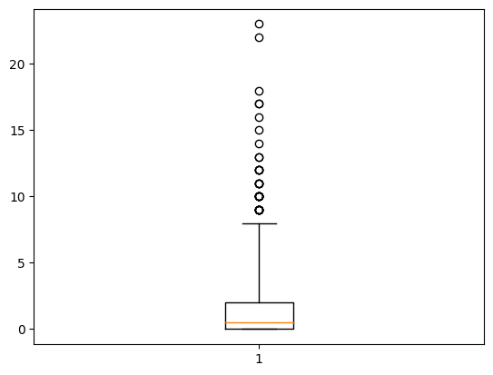

```python
plt.boxplot(df['Goals_Scored'], whis = 3)
```

```python
for i, j in enumerate(num_cols):
  print(i, j)
```

```
0 Goals_Scored
1 Assists
2 Total_Points
3 Minutes
4 Goals_Conceded
5 Creativity
6 Influence
7 Threat
8 Bonus
9 Clean_Sheets
```

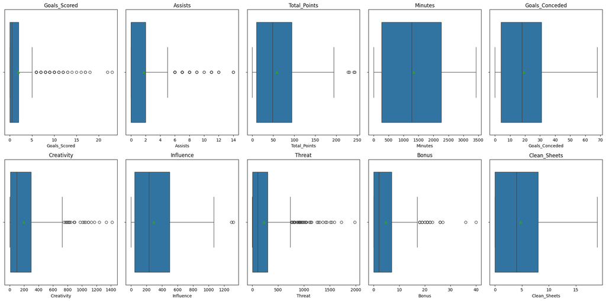

```python
plt.figure(figsize = (20, 10))
for i, j in enumerate(num_cols):
  plt.subplot(2, 5, i+1)
  sns.boxplot(df[j], orient='h', showmeans = True)
  plt.tight_layout()
  plt.title(j)
plt.show()
```

# Preprocessing Data

```python
from sklearn.preprocessing import StandardScaler
scaler = StandardScaler()
df_scaled = scaler.fit_transform(df[num_cols])
df_scaled
```

```
array([[-0.55260758, -0.64755534, -1.12250583, ..., -0.70763762,
        -0.75543496, -1.08112276],
       [ 3.21340088,  0.46120848,  1.37555959, ...,  1.79939343,
         2.60668787,  0.51352135],
       [-0.55260758, -0.64755534,  1.41459187, ..., -0.70134645,
         1.005677  ,  1.42474655],
       ...,
       [-0.55260758, -0.2779674 , -0.63460243, ..., -0.48115552,
        -0.75543496, -1.08112276],
       [-0.26291462, -0.2779674 , -0.36137652, ...,  0.09763208,
        -0.2751317 ,  0.05790874],
       [-0.26291462, -0.2779674 ,  0.18507529, ..., -0.13514119,
        -0.11503061,  0.28571505]])
```

```python
scaled_df = pd.DataFrame(df_scaled, columns = num_cols)
scaled_df
```

|  | Goals_Scored | Assists | Total_Points | Minutes | Goals_Conceded | Creativity | Influence | Threat | Bonus | Clean_Sheets |
| --- | --- | --- | --- | --- | --- | --- | --- | --- | --- | --- |
| 0 | -0.552608 | -0.647555 | -1.122506 | -1.232383 | -1.202653 | -0.780115 | -1.039325 | -0.707638 | -0.755435 | -1.081123 |
| 1 | 3.213401 | 0.461208 | 1.375560 | 0.539871 | 0.115663 | 0.443542 | 1.150596 | 1.799393 | 2.606688 | 0.513521 |
| 2 | -0.552608 | -0.647555 | 1.414592 | 1.672585 | 1.120094 | -0.780115 | 1.523682 | -0.701346 | 1.005677 | 1.424747 |
| 3 | 0.895857 | 1.200384 | 1.082818 | 1.134662 | 0.743432 | 1.809706 | 0.741621 | 2.387618 | 0.525374 | 0.741328 |
| 4 | -0.552608 | 0.461208 | -0.439441 | -0.546229 | -0.574884 | -0.105790 | -0.459134 | -0.465428 | -0.275132 | -0.625510 |
| ... | ... | ... | ... | ... | ... | ... | ... | ... | ... | ... |
| 471 | -0.552608 | -0.647555 | -1.122506 | -1.086016 | -0.763215 | -0.679404 | -0.984745 | -0.707638 | -0.755435 | -1.081123 |
| 472 | -0.552608 | -0.647555 | 1.434108 | 1.858107 | 1.998971 | -0.780115 | 1.753217 | -0.707638 | 1.165778 | 1.196940 |
| 473 | -0.552608 | -0.277967 | -0.634602 | -0.771839 | -0.700438 | -0.067576 | -0.802314 | -0.481156 | -0.755435 | -1.081123 |
| 474 | -0.262915 | -0.277967 | -0.361377 | -0.215271 | -0.386553 | -0.119723 | -0.766426 | 0.097632 | -0.275132 | 0.057909 |
| 475 | -0.262915 | -0.277967 | 0.185075 | 0.505377 | 0.617878 | -0.596606 | 0.446292 | -0.135141 | -0.115031 | 0.285715 |

476 rows × 10 columns

```python
(df['Goals_Scored'] - df['Goals_Scored'].mean()) / df['Goals_Scored'].std()
```

|  | Goals_Scored |
| --- | --- |
| 0 | -0.552027 |
| 1 | 3.210024 |
| 2 | -0.552027 |
| 3 | 0.894916 |
| 4 | -0.552027 |
| ... | ... |
| 471 | -0.552027 |
| 472 | -0.552027 |
| 473 | -0.552027 |
| 474 | -0.262638 |
| 475 | -0.262638 |

476 rows × 1 columns

**dtype:** float64

```python
#PCA
from sklearn.decomposition import PCA
pca = PCA(n_components=scaled_df.shape[1], random_state=0)
```

```python
pca.fit(scaled_df)
pca_df = pca.transform(scaled_df)
pca_df
```

```
array([[-2.91660039e+00,  5.69939118e-01, -4.18712595e-02, ...,
         6.47566658e-02, -5.74859356e-02, -6.26943054e-03],
       [ 3.81546834e+00,  1.99955411e+00, -2.21634470e+00, ...,
        -2.93053163e-01, -7.53558084e-02,  2.38019311e-01],
       [ 1.94339593e+00, -2.75744591e+00, -9.58237952e-01, ...,
         1.38392431e-01,  3.06182535e-01,  1.36656097e-01],
       ...,
       [-1.96663002e+00,  4.69243202e-01,  4.74988602e-01, ...,
         1.29321223e-01,  2.67968759e-01,  1.72718624e-02],
       [-8.17999711e-01,  1.80940456e-01,  1.03095534e-01, ...,
        -3.00399145e-01,  7.70535354e-04,  6.88056996e-02],
       [ 2.61543522e-01, -1.03286940e+00, -4.17138579e-01, ...,
         1.12067963e-01, -2.90157536e-02, -2.17703985e-03]])
```

```python
#pca_df = pd.DataFrame(pca_df)
pca_df = pd.DataFrame(pca_df, columns = ['PC' + str(i+1) for i in range(scaled_df.shape[1])])
pca_df
```

|  | PC1 | PC2 | PC3 | PC4 | PC5 | PC6 | PC7 | PC8 | PC9 | PC10 |
| --- | --- | --- | --- | --- | --- | --- | --- | --- | --- | --- |
| 0 | -2.916600 | 0.569939 | -0.041871 | 0.190663 | 0.003485 | 0.008158 | -0.042314 | 0.064757 | -0.057486 | -0.006269 |
| 1 | 3.815468 | 1.999554 | -2.216345 | 0.757341 | -0.119000 | -0.541975 | -0.233941 | -0.293053 | -0.075356 | 0.238019 |
| 2 | 1.943396 | -2.757446 | -0.958238 | 0.816920 | 0.041188 | 0.376978 | 0.005235 | 0.138392 | 0.306183 | 0.136656 |
| 3 | 3.502427 | 1.043441 | 0.581995 | -0.969567 | 0.415848 | -0.358456 | 0.661746 | 0.376272 | 0.260200 | 0.155934 |
| 4 | -1.153639 | 0.422189 | 0.642307 | 0.269271 | -0.271583 | 0.405367 | -0.033575 | 0.098886 | 0.035234 | 0.034877 |
| ... | ... | ... | ... | ... | ... | ... | ... | ... | ... | ... |
| 471 | -2.686929 | 0.350179 | 0.012579 | -0.028976 | -0.226985 | -0.079117 | -0.016498 | -0.025886 | -0.114191 | -0.056974 |
| 472 | 2.333559 | -3.137873 | -1.051056 | 0.486420 | -0.652311 | 0.294376 | 0.067490 | 0.094238 | 0.214251 | -0.007010 |
| 473 | -1.966630 | 0.469243 | 0.474989 | -0.098289 | -0.221093 | -0.163924 | -0.057647 | 0.129321 | 0.267969 | 0.017272 |
| 474 | -0.818000 | 0.180940 | 0.103096 | -0.112637 | 0.423414 | -0.064093 | 0.399416 | -0.300399 | 0.000771 | 0.068806 |
| 475 | 0.261544 | -1.032869 | -0.417139 | -0.260951 | -0.095053 | 0.293633 | 0.009004 | 0.112068 | -0.029016 | -0.002177 |

476 rows × 10 columns

```python
pca_df.var()/sum(pca_df.var())
```

|  | 0 |
| --- | --- |
| PC1 | 0.721489 |
| PC2 | 0.136593 |
| PC3 | 0.058800 |
| PC4 | 0.031384 |
| PC5 | 0.022745 |
| PC6 | 0.015227 |
| PC7 | 0.007008 |
| PC8 | 0.003937 |
| PC9 | 0.001945 |
| PC10 | 0.000870 |

**dtype:** float64

```python
print(pca.explained_variance_)
pca.explained_variance_ratio_
print(sum(pca.explained_variance_ratio_[0:5]))
```

```
[7.23008264 1.36881028 0.58924074 0.31449857 0.22793338 0.15259332
 0.07022566 0.03945534 0.01949385 0.00871885]
0.9710123249796083
```

# K-Means Clustering - Elbow Method

```python
from sklearn.cluster import KMeans
from sklearn.preprocessing import StandardScaler
from sklearn.decomposition import PCA

model = KMeans(n_clusters=4, random_state=0)
model.fit(pca_df)
```

```
KMeans(n_clusters=4, random_state=0)
```

```python
model.predict(pca_df)
```

```
array([1, 0, 2, 0, 1, 1, 2, 1, 1, 2, 2, 1, 2, 2, 2, 1, 1, 1, 1, 0, 1, 0,
       1, 2, 1, 1, 1, 2, 1, 2, 1, 0, 0, 1, 1, 2, 2, 2, 1, 3, 1, 1, 0, 1,
       1, 1, 2, 1, 0, 2, 1, 3, 1, 2, 2, 1, 1, 2, 2, 1, 1, 1, 2, 1, 2, 0,
       1, 1, 1, 1, 2, 1, 0, 0, 1, 0, 0, 1, 1, 2, 2, 1, 1, 2, 1, 2, 0, 1,
       2, 2, 0, 1, 0, 1, 1, 2, 2, 1, 1, 1, 1, 1, 2, 1, 1, 2, 2, 2, 1, 1,
       1, 2, 2, 0, 1, 2, 2, 2, 2, 1, 1, 1, 2, 0, 2, 1, 1, 2, 1, 3, 2, 2,
       1, 0, 2, 2, 3, 1, 1, 0, 2, 0, 1, 0, 2, 1, 2, 2, 1, 1, 1, 2, 2, 2,
       2, 1, 1, 1, 1, 1, 2, 1, 1, 1, 1, 1, 2, 2, 0, 2, 2, 2, 2, 1, 2, 1,
       1, 3, 1, 0, 0, 1, 1, 2, 1, 0, 2, 2, 1, 1, 1, 0, 1, 2, 1, 2, 1, 1,
       2, 1, 1, 2, 1, 2, 0, 1, 1, 1, 1, 2, 1, 1, 2, 2, 1, 0, 1, 1, 2, 3,
       0, 1, 0, 0, 1, 2, 2, 1, 1, 1, 1, 1, 1, 1, 0, 1, 2, 0, 3, 2, 2, 0,
       1, 2, 1, 1, 1, 1, 2, 1, 1, 2, 2, 0, 1, 1, 2, 0, 1, 1, 1, 2, 1, 2,
       2, 1, 1, 2, 1, 3, 1, 2, 1, 1, 1, 3, 3, 2, 0, 1, 1, 1, 1, 0, 2, 1,
       2, 2, 0, 0, 0, 2, 3, 2, 1, 1, 1, 1, 2, 0, 3, 0, 2, 2, 1, 1, 1, 1,
       0, 1, 1, 1, 2, 1, 1, 3, 1, 2, 1, 0, 1, 2, 1, 2, 1, 0, 3, 0, 1, 1,
       1, 0, 2, 1, 2, 1, 2, 1, 0, 2, 1, 1, 1, 1, 1, 2, 1, 2, 2, 2, 2, 1,
       2, 2, 2, 2, 1, 1, 2, 1, 2, 1, 1, 1, 1, 2, 1, 0, 1, 0, 1, 1, 2, 1,
       0, 2, 2, 1, 2, 1, 1, 1, 2, 1, 2, 2, 1, 0, 1, 2, 1, 1, 1, 1, 1, 1,
       1, 1, 1, 2, 1, 0, 1, 3, 1, 3, 2, 1, 1, 1, 2, 1, 1, 1, 2, 1, 2, 2,
       1, 2, 2, 0, 1, 1, 1, 2, 1, 1, 2, 1, 2, 1, 1, 1, 1, 1, 0, 0, 1, 2,
       1, 1, 0, 0, 1, 1, 2, 1, 0, 0, 0, 2, 2, 2, 1, 2, 1, 1, 1, 2, 1, 1,
       2, 1, 1, 1, 0, 1, 2, 2, 0, 1, 2, 1, 1, 2], dtype=int32)
```

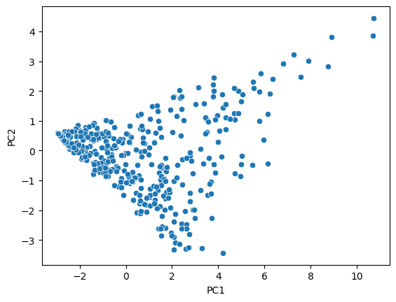

```python
sns.scatterplot(x=pca_df.iloc[:, 0], y=pca_df.iloc[:, 1])
```

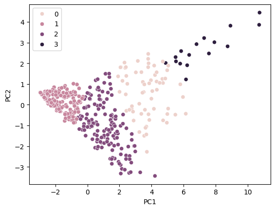

```python
sns.scatterplot(x=pca_df.iloc[:, 0], y=pca_df.iloc[:, 1], hue = model.predict(pca_df))
```

```python
model.predict(pca_df).shape
print(pca_df.head())
pca_df.iloc[:, 0]
pca_df.iloc[:, 1]
```

```
        PC1       PC2       PC3       PC4       PC5       PC6       PC7  \
0 -2.916600  0.569939 -0.041871  0.190663  0.003485  0.008158 -0.042314
1  3.815468  1.999554 -2.216345  0.757341 -0.119000 -0.541975 -0.233941
2  1.943396 -2.757446 -0.958238  0.816920  0.041188  0.376978  0.005235
3  3.502427  1.043441  0.581995 -0.969567  0.415848 -0.358456  0.661746
4 -1.153639  0.422189  0.642307  0.269271 -0.271583  0.405367 -0.033575

        PC8       PC9      PC10
0  0.064757 -0.057486 -0.006269
1 -0.293053 -0.075356  0.238019
2  0.138392  0.306183  0.136656
3  0.376272  0.260200  0.155934
4  0.098886  0.035234  0.034877
```

|  | PC2 |
| --- | --- |
| 0 | 0.569939 |
| 1 | 1.999554 |
| 2 | -2.757446 |
| 3 | 1.043441 |
| 4 | 0.422189 |
| ... | ... |
| 471 | 0.350179 |
| 472 | -3.137873 |
| 473 | 0.469243 |
| 474 | 0.180940 |
| 475 | -1.032869 |

476 rows × 1 columns

**dtype:** float64

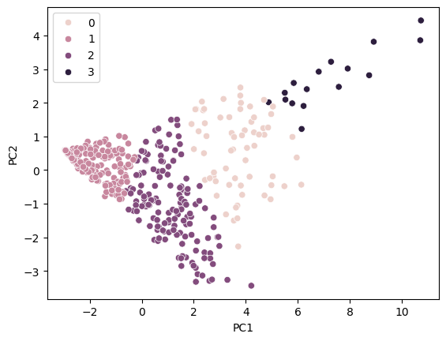

```python
sns.scatterplot(x=pca_df.iloc[:, 0], y=pca_df.iloc[:, 1], hue = model.predict(pca_df))
```

```python
# from scipy.spatial.distance import cdist
# clusters_ = range(1, 11)
# #inertia = []
# distortion = []

# for i in clusters_:
#     model = KMeans(n_clusters=i, random_state=0)
#     model.fit(pca_df)
#     #inertia.append(model.inertia_)
#     #distortion.append(model.inertia_)

#     distortion.append(sum(np.min(cdist(pca_df, model.cluster_centers_), axis=1))/pca_df.shape[0])
```

```python
distortion
```

```
[2.773037110097803,
 1.863573678589826,
 1.5628794778061599,
 1.4995313622234188,
 1.2924554544010316,
 1.2315513569060248,
 1.1565713591082718,
 1.093444810848494,
 1.0523440681991765,
 1.0257779034813685]
```

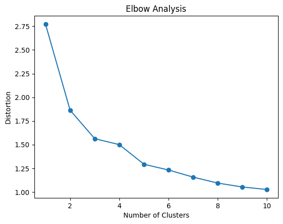

```python
plt.plot(clusters_, distortion, marker='o')
plt.xlabel('Number of Clusters')
plt.ylabel('Distortion')
plt.title('Elbow Analysis')
plt.show()
```